# STA101 - HW 5

Wangqian Miao

### Problem 1

**(a)**

```
##   shot age aware gender
## 1    0  59    52      F
## 2    0  61    55      M
## 3    1  82    51      F
## 4    0  51    70      F
## 5    0  53    70      F
## 6    0  62    49      M
```

```
## Start:  AIC=136.94
## shot ~ 1
##
##          Df Deviance    AIC
## + aware   1   113.20 117.20
## + age     1   116.27 120.27
## + gender  1   132.88 136.88
## <none>        134.94 136.94
##
## Step:  AIC=117.2
## shot ~ aware
##
##          Df Deviance    AIC
## + age     1   105.80 111.80
## + gender  1   111.19 117.19
## <none>        113.20 117.20
##
## Step:  AIC=111.8
## shot ~ aware + age
##
##          Df Deviance    AIC
## <none>        105.80 111.80
## + gender  1   105.09 113.09
```

```
##
## Call:  glm(formula = shot ~ aware + age, family = binomial(link = logit),
##     data = flu)
##
## Coefficients:
## (Intercept)        aware          age
##    -1.45778     -0.09547      0.07787
##
## Degrees of Freedom: 158 Total (i.e. Null);  156 Residual
## Null Deviance:       134.9
## Residual Deviance: 105.8     AIC: 111.8
```

$X_1$ and $X_2$ are included in the final model.

**(b)**

```
## Start:  AIC=113.09
## shot ~ age + aware + gender
##
##          Df Deviance    AIC
## - gender  1   105.80 111.80
## <none>        105.09 113.09
## - age     1   111.19 117.19
## - aware   1   115.80 121.80
##
## Step:  AIC=111.8
## shot ~ age + aware
##
##         Df Deviance    AIC
## <none>       105.80 111.80
## - age    1   113.20 117.20
## - aware  1   116.27 120.27
```

```
##
## Call:  glm(formula = shot ~ age + aware, family = binomial(link = logit),
##     data = flu)
##
## Coefficients:
## (Intercept)          age        aware
##    -1.45778      0.07787     -0.09547
##
## Degrees of Freedom: 158 Total (i.e. Null);  156 Residual
## Null Deviance:       134.9
## Residual Deviance: 105.8     AIC: 111.8
```

$X_1$ and $X_2$ are included in the final model.

**(c)**

The logistic regression model is:  
$\ln\frac{\hat{\pi}}{1-\hat{\pi}}= -1.45778+0.07787X_1-0.09547X_2$. This model’s log-likelihood is -52.8976936.

**(d)**

The log-likelihood is -52.8751729 after adding the iteraction term.

**(e)**

**(f)**

P-value is larger than 0.05 then we fail to reject null and and conclude that the interaction term should be dropped.

### Problem 2

**(a)**

```
## (Intercept)       aware         age
##   0.2327517   0.9089435   1.0809847
```

The odds of getting a shot flu will be 1.081 times what is was when the age increases one year, holding other variables constant.

**(b)**

The odds of getting a shot flu will be 0.9089 times what is was when the health awareness score increases one unit, holding other variables constant.

**(c)**

```
##         1
## 0.1427452
```

The estimated possibility for this person to get the flu is 0.1427, so the conclusion is that he would not get the flu.

**(d)**

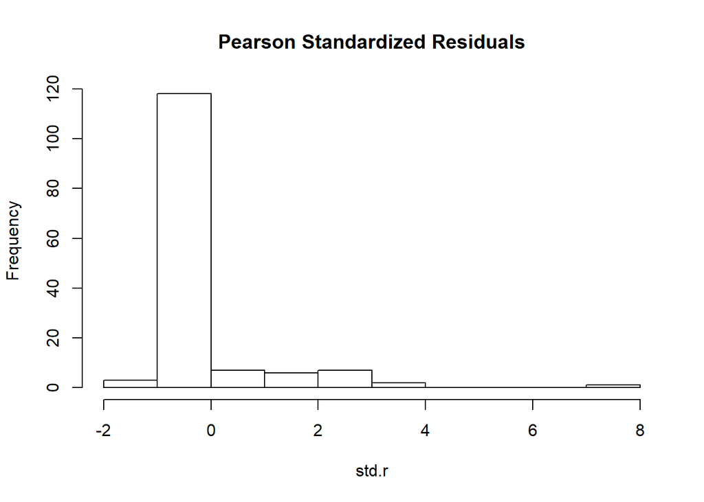

```
## [1] 7.511965
```

```
##    (Intercept) aware age y          P n       yhat       Pr       dr
## 1:           1    75  59 1 0.01757171 1 0.01757171 7.477275 2.843049
##              h      sPr      sdr   dChisq     dDev    dBhat
## 1: 0.009214369 7.511965 2.856239 56.42961 8.158102 0.524799
```

There exists.

**(e)**

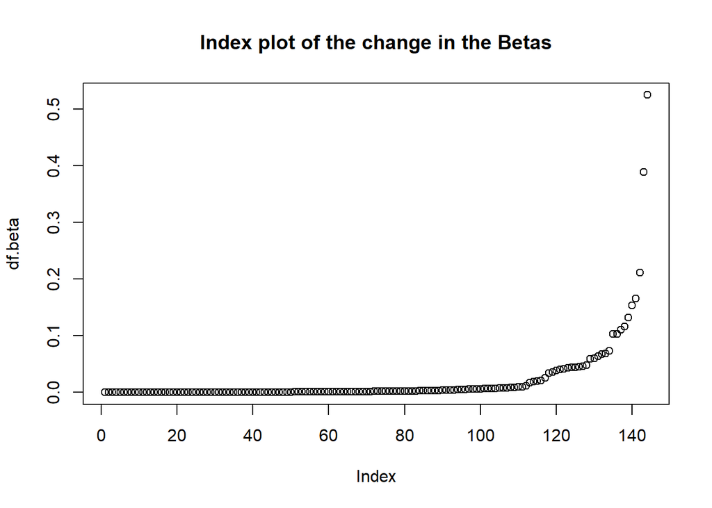

```
## [1] 0.3885274 0.5247990
```

```
##    (Intercept) aware age y          P n       yhat       Pr       dr
## 1:           1    42  51 1 0.18300345 1 0.18300345 2.112907 1.842960
## 2:           1    75  59 1 0.01757171 1 0.01757171 7.477275 2.843049
##              h      sPr      sdr    dChisq     dDev     dBhat
## 1: 0.074538023 2.196348 1.915740  4.823945 3.670059 0.3885274
## 2: 0.009214369 7.511965 2.856239 56.429612 8.158102 0.5247990
```

As shown in the table, there exists.

### Problem 3

**(a)**

```
##     con age edu working
## 1  None  33   G       N
## 2  None  31   A       N
## 3  Long  38   A       N
## 4 Short  41   A       N
## 5  Long  25   M       N
## 6  Long  40   M       Y
```

```
## trying + age
## trying + edu
## trying + working
## trying + age
## trying + working
## trying + working
```

```
## Call:
## multinom(formula = con ~ edu + age, data = control, trace = FALSE)
##
## Coefficients:
##       (Intercept)       eduG        eduL       eduM        age
## None    -1.031659 -0.6054868  -0.1114698 -0.3608938 0.05140516
## Short   -3.683428  0.4272499 -10.6328484 -2.2720652 0.10534161
##
## Std. Errors:
##       (Intercept)      eduG         eduL      eduM        age
## None    0.6105538 0.3536421 5.034946e-01 0.3711520 0.01808688
## Short   0.8114100 0.4010035 5.862023e-05 0.8087724 0.02234756
##
## Residual Deviance: 557.497
## AIC: 577.497
```

$X_1$ and $X_2$ are included in this model.

**(b)**

```
## trying - age
## trying - edu
## trying - working
## trying - age
## trying - edu
```

```
## Call:
## multinom(formula = con ~ age + edu, data = control, trace = FALSE)
##
## Coefficients:
##       (Intercept)        age       eduG        eduL       eduM
## None    -1.031659 0.05140516 -0.6054868  -0.1114698 -0.3608938
## Short   -3.683428 0.10534161  0.4272499 -10.6328484 -2.2720652
##
## Std. Errors:
##       (Intercept)        age      eduG         eduL      eduM
## None    0.6105538 0.01808688 0.3536421 5.034946e-01 0.3711520
## Short   0.8114100 0.02234756 0.4010035 5.862023e-05 0.8087724
##
## Residual Deviance: 557.497
## AIC: 577.497
```

$X_1$ and $X_2$ are included in the model.

**(c)**

```
## Call:
## multinom(formula = con ~ edu + age, data = control, trace = FALSE)
##
## Coefficients:
##       (Intercept)       eduG        eduL       eduM        age
## None    -1.031659 -0.6054868  -0.1114698 -0.3608938 0.05140516
## Short   -3.683428  0.4272499 -10.6328484 -2.2720652 0.10534161
##
## Std. Errors:
##       (Intercept)      eduG         eduL      eduM        age
## None    0.6105538 0.3536421 5.034946e-01 0.3711520 0.01808688
## Short   0.8114100 0.4010035 5.862023e-05 0.8087724 0.02234756
##
## Residual Deviance: 557.497
## AIC: 577.497
```

This gives us the following models for the two log-odds: $\ln\frac{\pi_{none}}{\pi_{Long}}=-1.031659-0.6054868X_{eduG} -0.1114698X_{eduL} -0.3608938X_{eduM}+0.05140516X_1$.  
$\ln\frac{\pi_{short}}{\pi_{Long}}= -3.683428+0.4272499X_{eduG} -10.6328484X_{eduL} -2.2720652X_{eduM}+ 0.10534161X_1$.

**(d)**

The relative probability of bing birth control none vs birth control long is 1.0527 times what it was when the age increases one year.

**(e)**

The relative probability of bing birth control short vs birth control long for is 1.1111 times what it was when the age increases one year.

### Problem 4

**(a)**

**(b)**

**(c)**

```
## 'log Lik.' 56.37099 (df=4)
```

```
## 'log Lik.' 1 (df=4)
```

**(d)**

### Problem 5

**(a)**

```
## [1] "Long"  "None"  "Short"
```

```
##
## Call:
## glm(formula = con ~ age + edu, family = binomial(logit), data = LvsS)
##
## Deviance Residuals:
##     Min       1Q   Median       3Q      Max
## -1.9153  -0.8666  -0.2704   0.8582   2.4992
##
## Coefficients:
##               Estimate Std. Error z value Pr(>|z|)
## (Intercept)   -3.79679    0.93598  -4.056 4.98e-05 ***
## age            0.10635    0.02604   4.084 4.42e-05 ***
## eduG           0.45829    0.41230   1.112   0.2663
## eduL         -17.43587 1200.31119  -0.015   0.9884
## eduM          -1.94005    0.81914  -2.368   0.0179 *
## ---
## Signif. codes:  0 '***' 0.001 '**' 0.01 '*' 0.05 '.' 0.1 ' ' 1
##
## (Dispersion parameter for binomial family taken to be 1)
##
##     Null deviance: 229.28  on 168  degrees of freedom
## Residual deviance: 172.11  on 164  degrees of freedom
## AIC: 182.11
##
## Number of Fisher Scoring iterations: 16
```

The model is $\ln\frac{\pi_{s}}{\pi_{l}}=-3.796+0.1064X_1+0.4583X_{eduG}-17.4359X_{eduL}-1.9400X_{eduM}$

**(b)**

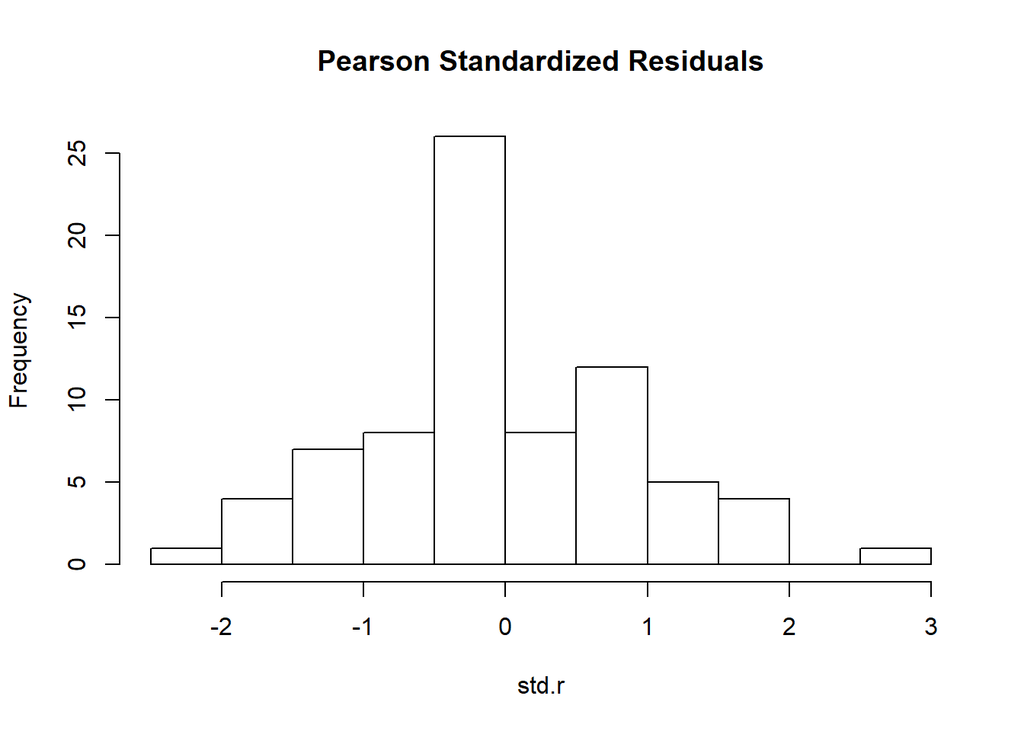

There is no observations larger than 3 or smaller than -3.

**(c)**

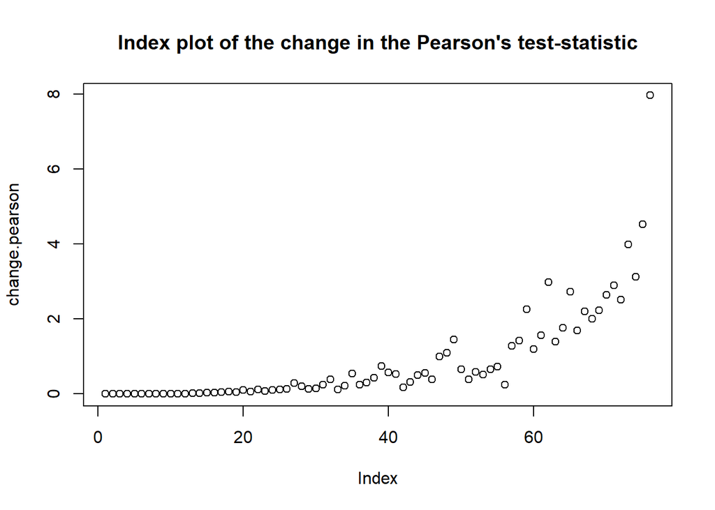

```
## numeric(0)
```

```
## Empty data.table (0 rows) of 17 cols: (Intercept),age,eduG,eduL,eduM,y...
```

There is no observation larger than 8.

**(d)**

No observations should be removed because there is no outliers in standardized residuals and in test statistics,

### Problem 6

**(a)**

FALSE An influential point is not necessarily an outlier. It may be repeated rows in the dataset.

**(b)**

FALSE  
They will have different $\beta s$ for all sub-models.

**(c)**

FALSE  
When we reject null, we will conclude that a larger model is better.

**(d)**

FALSE  
The standarded residual is usual when it is between -3 and 3.

### Problem 7

**(a)**

```
##                Beef  Cereal    Pork
## Means       89.6000 84.9000 89.1000
## Std. Dev    17.7123 14.9944 17.3202
## Sample size 20.0000 20.0000 20.0000
```

**(b)**

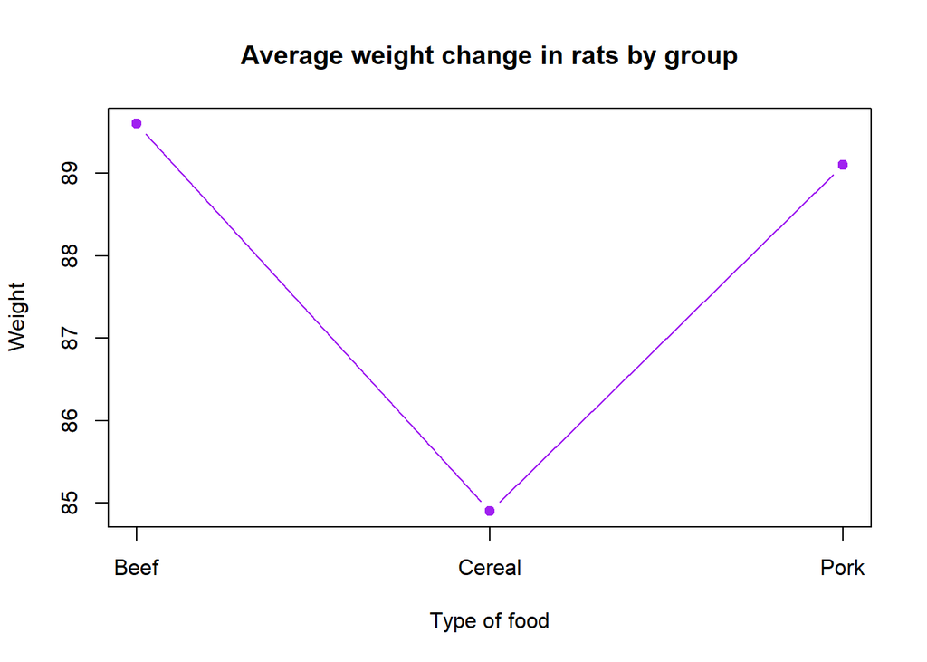

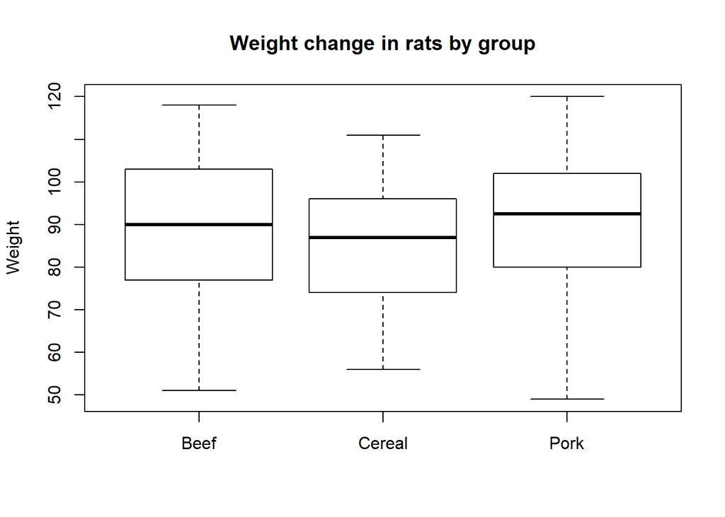

There seems to exist a difference between group Cereal and other groups.

**(c)**

$H_0$: The smaller model fits better. $H_A$: The larger model fits better. The F-test is : $F_s=\frac{SSE_{s}-SSE_{L}}{d.f_{s}-d.f_{L}}/ \frac{SSE_{L}}{d.f_{L}}$

**(d)**

```
## Analysis of Variance Table
##
## Model 1: Weight ~ 1
## Model 2: Weight ~ Type
##   Res.Df   RSS Df Sum of Sq      F Pr(>F)
## 1     59 16199
## 2     57 15932  2    266.53 0.4768 0.6232
```

Test-statistic equals 0.4768. P-value equals 0.6232.

**(e)** The p-value is large enough and we fail to reject $H_0$, the conclusion is that smaller model is better and there is no significant difference in the mean of different group.

### Problem 8

**(a)**

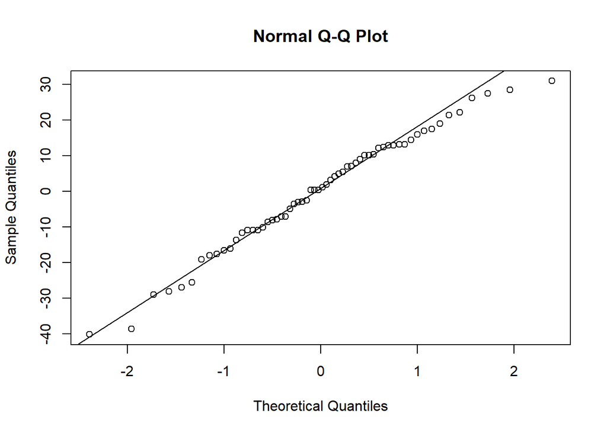

The data seems approximately normal according to qq-plot.

**(b)**

```
##
##  Shapiro-Wilk normality test
##
## data:  the.model$residuals
## W = 0.98194, p-value = 0.516
```

$H_0$: The data is normally distributed.  
$H_A$: The data is not normally distributed.  
The P-value of S-W test is 0.516. It is large enough and we fail to reject $H_0$ and conclude that the data is normally distributed.

**(c)**

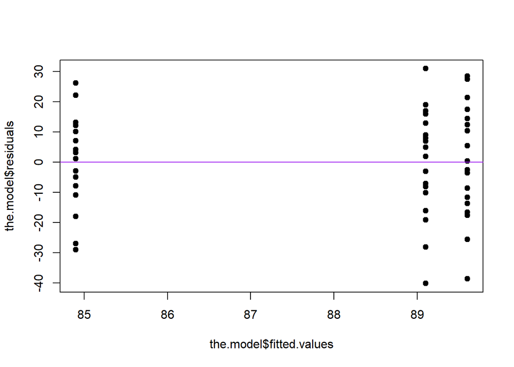

**(d)**

```
##
## Modified Levene's test of homogeneity of variances
##
## df1 = 2,  df2 = 57,  F = 0.17997,  p-value = 0.83577
```

The p-value equals 0.8358. It is large enough and we will fail to reject $H_0$ and conclude that the variance between groups is constant.

**(e)**

According to the above problems, the assumptions of ANOVA are met.

### R Appendix

```r
flu=read.csv("flu.csv",header = TRUE)
head(flu)
empty.model=glm(shot~1,data=flu,family = binomial(link=logit))
full.model=glm(shot~.,data=flu,family=binomial(link = logit))
step(empty.model,scope = list(lower = empty.model, upper = full.model),direction = "forward")
step(full.model,scope = list(lower = empty.model, upper = full.model),direction = "backward")
model.a=glm(shot~aware+age,data=flu,family=binomial(link = logit))
LLA=logLik(model.a)
model.b=glm(shot~aware+age+aware*age,data=flu,family=binomial(link = logit))
LLB=logLik(model.b)
#model.b$coefficients
pa = length(model.a$coefficients)
pb = length(model.b$coefficients)
LR = -2*(LLA - LLB)
p.value = pchisq(LR, df=pb-pa)
the.betas=model.a$coefficients
exp.betas=exp(the.betas)
exp.betas

x.star=data.frame(age=57,gender="M",aware=50)
my.predict = predict(model.a,x.star,type = "response")
my.predict

library(LogisticDx)
good.stuff = dx(model.a)
pear.r = good.stuff$Pr #Pearsons Residuals
std.r = good.stuff$sPr #Standardized residuals (Pearson)
df.beta = good.stuff$dBhat #DF Beta for removing each observation
change.pearson = good.stuff$dChisq #Change in pearson X^2 for each observation
hist(std.r, main = "Pearson Standardized Residuals")
cutoff.std = 4.0
std.r[std.r > cutoff.std]
good.stuff[std.r > cutoff.std]
plot(df.beta,main = "Index plot of the change in the Betas")
cutoff.beta = .30
df.beta[df.beta > cutoff.beta] #Shows the values of df.Beta
good.stuff[df.beta > cutoff.beta,]
library(nnet)
control=read.csv("control.csv",header = TRUE)
head(control)
full.model = multinom(con~ .,data = control,trace = FALSE)
null.model = multinom(con ~ 1,data = control,trace = FALSE)
forward.model = step(null.model, scope = list(lower = null.model, upper = full.model), direction = "forward",trace = FALSE)
summary(forward.model)
library(nnet)
full.model = multinom(con~ .,data = control,trace = FALSE)
null.model = multinom(con ~ 1,data = control,trace = FALSE)
backward.model = step(full.model, scope = list(lower = null.model, upper = full.model), direction = "backward",trace = FALSE)
summary(backward.model)
summary(forward.model)



model.0 = multinom(con~ age,data = control,trace = FALSE)
model.a = multinom(con~ age+edu,data = control,trace = FALSE)
LLA=logLik(model.a)
LL0=logLik(model.0)
#pA = length(model.a$coefficients)
pA = length(coef(model.a))
#p0 = length(model.0$coefficients)
p0 = length(coef(model.0))
LR = -2*(LL0 - LLA)
p.value = pchisq(LR, df= pA-p0)
LR
p.value

spilt.data = split(control, control$con)
names(spilt.data)
LvsS=rbind(spilt.data[[1]], spilt.data[[3]])
model.LvsS= glm(con ~ age + edu, data = LvsS, family = binomial(logit))
summary(model.LvsS)
library(LogisticDx)
good.stuff = dx(model.LvsS)
pear.r = good.stuff$Pr #Pearsons Residuals
std.r = good.stuff$sPr #Standardized residuals (Pearson)
df.beta = good.stuff$dBhat #DF Beta for removing each observation
change.pearson = good.stuff$dChisq #Change in pearson X^2 for each observation
hist(std.r, main = "Pearson Standardized Residuals")
plot(change.pearson,main = "Index plot of the change in the Pearson's test-statistic")
cutoff.pearson = 8
change.pearson[change.pearson > cutoff.pearson] #Shows the values
good.stuff[change.pearson > cutoff.pearson] #Shows the values of my columns (colum names are specific to your dataset),and the values of the change in Pearson (which is called dChisq in original dataframe).





library(ggplot2)
library(pROC)
library(nnet)
library(LogisticDx)
library(asbio)
rat=read.csv("rat.csv")
group.means = by(rat$Weight, rat$Type, mean)
group.sds = by(rat$Weight, rat$Type, sd)
group.nis = by(rat$Weight, rat$Type, length)
the.summary=rbind(group.means, group.sds, group.nis)
the.summary = round(the.summary,digits=4)
colnames(the.summary) = names(group.means)
rownames(the.summary) = c("Means","Std. Dev","Sample size")
the.summary
plot(group.means,xaxt="n",pch=19,col="purple",xlab = "Type of food", ylab="Weight",main="Average weight change in rats by group", type="b")
axis(1,1:length(group.means),names(group.means))
boxplot(rat$Weight~rat$Type,main="Weight change in rats by group",ylab="Weight")

larger.model=lm(Weight~Type,data = rat)
smaller.model=lm(Weight~1,data = rat)
anova.table=anova(smaller.model, larger.model)
anova.table
the.model = larger.model
qqnorm(the.model$residuals)
qqline(the.model$residuals)
sw.test = shapiro.test(the.model$residuals)
sw.test
plot(the.model$fitted.values,the.model$residuals, pch=19)
abline(h=0,col="purple")
ML.test = modlevene.test(the.model$residuals, rat$Type)
ML.test
```